# Client Report - Can You Predict That?

- Show All Code
- Hide All Code

Course DS 250

Author

Matthew Foushee

```python
import pandas as pd
import numpy as np
from plotnine import *
# add the additional libraries you need to import for ML here
```

```python
# Learn morea about Code Cells: https://quarto.org/docs/reference/cells/cells-jupyter.html

# Include and execute your code here

# import your data here using pandas and the URL
df = pd.read_csv("dwellings_ml.csv")
```

## QUESTION|TASK 1

**Create 2-3 charts that evaluate potential relationships between the home variables and `before1980`.** Explain what you learn from the charts that could help a machine learning algorithm.

This first code block helped me learn which variable I would like to look more into.

```python
# Include and execute your code here
# columns = df.columns

# toskip = ['parcel', 'yrbuilt']
# counter = 1

# for column in columns:
#   if column in toskip:
#     continue
#   print(f"Now doing {column}")
#   p = ggplot(df) + geom_point(aes(x='yrbuilt', y=column)) + ggtitle(f"{column}")
#   filename = counter
#   counter += 1
#   p.save(f'images/{filename}.png', width=6, height=4)
#   (
#   ggplot(df) + geom_bar(aes(x='gartype_att/CP', y='before1980')) + ggtitle('gartype_att/CP')
# )
```

```python
# Include and execute your code here

df["AgeGroup"] = df["before1980"].map({0: "1980 or Later", 1: "Before 1980"})

# Create GarageType column
df["GarageType"] = df[["gartype_Att", "gartype_Det"]].idxmax(axis=1).str.replace("gartype_", "")
```

After 1980 the sqft area of homes tended to be bigger

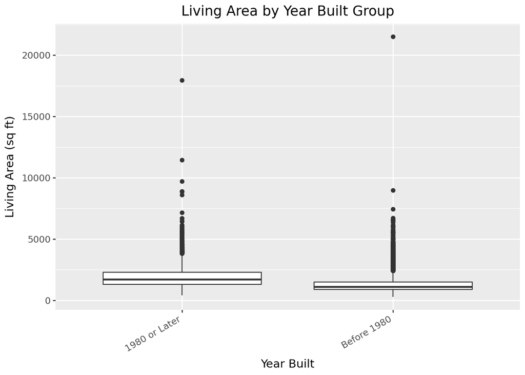

```python
# 1. Living Area by Year Built
plot1 = (
    ggplot(df, aes(x="AgeGroup", y="livearea"))
    + geom_boxplot()
    + labs(
        title="Living Area by Year Built Group",
        x="Year Built",
        y="Living Area (sq ft)"
    )
    + theme(
        axis_text_x=element_text(rotation=30, ha="right")
    )
)
plot1
```

Older homes tended to have one or two bathrooms while nother homes tended to have 2 or 3

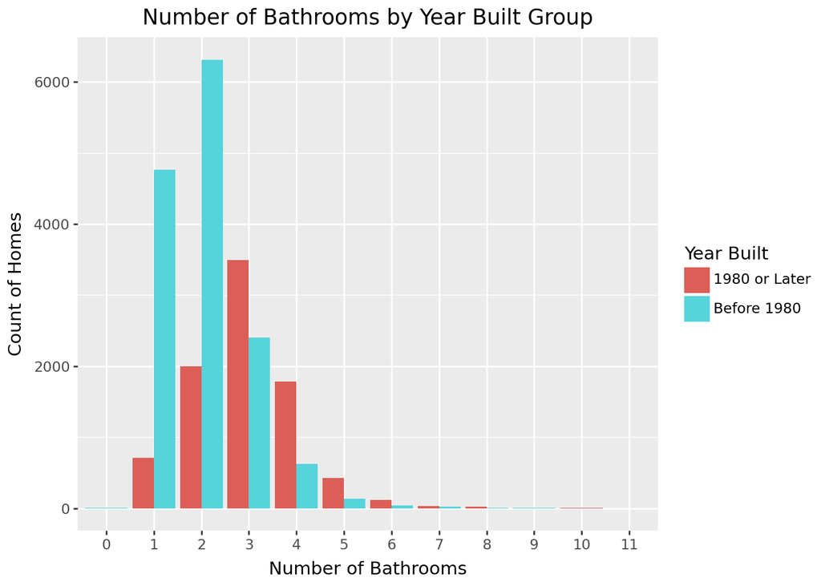

```python
# 2. Number of Bathrooms by Year Built
plot2 = (
    ggplot(df, aes(x="factor(numbaths)", fill="AgeGroup"))
    + geom_bar(position=position_dodge())
    + labs(
        title="Number of Bathrooms by Year Built Group",
        x="Number of Bathrooms",
        y="Count of Homes",
        fill="Year Built"
    )
    + theme(
        axis_text_x=element_text(rotation=0)
    )
)
plot2
```

Homes built before 1980 more often has detached garages while nerver ones tend to have attached ones.

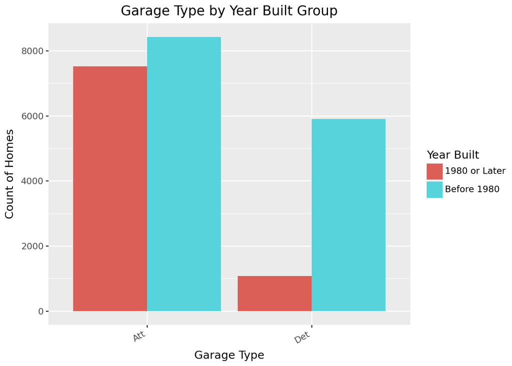

```python
# 3. Garage Type by Year Built
plot3 = (
    ggplot(df, aes(x="GarageType", fill="AgeGroup"))
    + geom_bar(position=position_dodge())
    + labs(
        title="Garage Type by Year Built Group",
        x="Garage Type",
        y="Count of Homes",
        fill="Year Built"
    )
    + theme(
        axis_text_x=element_text(rotation=30, ha="right")
    )
)
plot3
```

## QUESTION|TASK 2

**Build a classification model labeling houses as being built “before 1980” or “during or after 1980”.** Your goal is to reach or exceed 90% accuracy. Explain your final model choice (algorithm, tuning parameters, etc) and describe what other models you tried.

I tried GaussianNB, it gave a 60-70% accurracy I then tried this RandomForestClassifier, it at first was ALWAYS giving me a 100% accuracy. After some better understanding i realized it had access to the yrbuilt variable which basically gave the algorithm the answer. After not giving it access to that, it now has a 90-92% accuracy.

```python
# Include and execute your code here
from sklearn.model_selection import train_test_split
from sklearn.ensemble import RandomForestClassifier
from sklearn.metrics import accuracy_score, classification_report

features = df.drop(columns=["parcel", "before1980", "AgeGroup", "GarageType", "yrbuilt", "syear"])
#features = pd.get_dummies(features)

targets = df["before1980"]

train_data, test_data, train_targets, test_targets = train_test_split(features, targets, test_size=0.3)

clf = RandomForestClassifier(n_estimators=200)
clf.fit(train_data, train_targets)

targets_predicted = clf.predict(test_data)

accuracy = accuracy_score(test_targets, targets_predicted)

print(f"Test Targets: {len(test_targets)}")
print(f"Test Targets: {len(targets_predicted)}")
print(f"Accuracy: {accuracy:.3f}")
print(classification_report(test_targets, targets_predicted))
```

```
Test Targets: 6874
Test Targets: 6874
Accuracy: 0.921
              precision    recall  f1-score   support

           0       0.91      0.89      0.90      2661
           1       0.93      0.94      0.94      4213

    accuracy                           0.92      6874
   macro avg       0.92      0.92      0.92      6874
weighted avg       0.92      0.92      0.92      6874
```

## QUESTION|TASK 3

**Justify your classification model by discussing the most important features selected by your model.** This discussion should include a feature importance chart and a description of the features.

```python
# Include and execute your code here
importances = clf.feature_importances_
feature_names = train_data.columns

feat_imp_df = pd.DataFrame({
    "Feature": feature_names,
    "Importance": importances
}).sort_values(by="Importance", ascending=False)
feat_imp_df.head(10)
```

|  | Feature | Importance |
| --- | --- | --- |
| 1 | livearea | 0.087567 |
| 36 | arcstyle_ONE-STORY | 0.080227 |
| 5 | stories | 0.068145 |
| 8 | numbaths | 0.062478 |
| 11 | netprice | 0.060647 |
| 9 | sprice | 0.060459 |
| 12 | tasp | 0.060189 |
| 24 | gartype_Att | 0.049100 |
| 3 | basement | 0.041909 |
| 21 | quality_C | 0.039484 |

## QUESTION|TASK 4

**Describe the quality of your classification model using 2-3 different evaluation metrics.** You also need to explain how to interpret each of the evaluation metrics you use.

The 3 different evaluation metrics I will be using are: Accuracy, Precision, and recall

The Accuracy is the overall ratio of how many did it say were built before 1980 vs how many were actually made before: Accuracy = predicted_count/correct_count Accuracy = 0.80 means 80% of the samples were predicted correctly.

The Precision is how many of the predicated are actually built before 1980 or positive. Precision = True Positives/(True positives + False Positives) Precision = 0.85 means that 85% of homes predicted as “before 1980” actually are.

The recall measures of all the acuall positive samples jpw many did the model correctly identify. Recall = True Positives/(True Positives + False Negatives) Recall = 0.75 means the model correctly found 75% of the old homes.

I trust/like the recall metric the most.

```python
# Include and execute your code here
from sklearn.metrics import accuracy_score, precision_score, recall_score
accuracy = accuracy_score(test_targets, targets_predicted)
precision = precision_score(test_targets, targets_predicted)
recall = recall_score(test_targets, targets_predicted)


print(f"Accuracy: {accuracy:.3f}")
print(f"Precision: {precision:.3f}")
print(f"Recall: {recall:.3f}")
```

```
Accuracy: 0.921
Precision: 0.931
Recall: 0.942
```

## STRETCH QUESTION|TASK 1

**Repeat the classification model using 3 different algorithms.** Display their Feature Importance, and Decision Matrix. Explian the differences between the models and which one you would recommend to the Client.

```python
# Include and execute your code here
```

## STRETCH QUESTION|TASK 2

**Join the `dwellings_neighborhoods_ml.csv` data to the `dwelling_ml.csv` on the `parcel` column to create a new dataset. Duplicate the code for the stretch question above and update it to use this data.** Explain the differences and if this changes the model you recomend to the Client.

```python
# Include and execute your code here
```

## STRETCH QUESTION|TASK 3

**Can you build a model that predicts the year a house was built?** Explain the model and the evaluation metrics you would use to determine if the model is good.

```python
# Include and execute your code here
```